# Taking a Closer Look at Presidential Campaign Funding

### Spring 2024 Data Science Project

Group members: Christian Woo

## 1. Introduction

With this year being a presidential election year, I thought it would be interesting to take this project as an opportunity to see how presidential candidates both receive and spend money within their campaigns. In my exploration of the data, I answer a few questions:

1. Which candidates received the most independent expenditures, and which party received the most independent expenditures?
2. Which method of raising money was more likely to contribute more money to a candidate's campaign?
3. What categories of expenses do most independent expenditures go towards covering?

Then, with the context from the data exploration, my primary analysis aims to see which candidates are more "grassroots" -- in other words, which candidates tend to receive more of their support from smaller size contributions. In theory, these smaller contributions are more likely to come from ordinary people, rather than the top 1% or big corporations. Then, I would like to see how these proportions correlate to a candidate's total contributions: are the best-funded candidates receiving a lot of support from ordinary people, or not? This question is important because there are always a few candidates whose ethos relies on the idea of "looking out for the common person." I would like to put this idea to the test by seeing where their contribtions come from.

## 2.Data Curation

The datasets I will be using come from the [Federal Election Commission](https://www.fec.gov/data/), or FEC, who make a wide variety of campaign financial information public.

The dataset I will be using for the data exploration contains independent expenditures from the years 2021-2024 -- so expenditures roughly since last presidential election.

An independent expenditure is an expenditure for a communication that expressly advocates the election or defeat of a clearly identified candidate and which is not made in coordination with any candidate or their campaign or political party. Essentially, it's a donation by a person or organization to a political candidate with whom they have no ties.

```python
import pandas as pd
import numpy as np
import scipy.stats
import matplotlib.pyplot as plt
import statsmodels.api as sm
```

First, let's clean the dataset a little. There are many columns that are either unneeded for the analyses we will run or mostly blank.

```python
df = pd.read_csv("independent_expenditures_2021-2024.csv")
columns_to_keep = ['committee_id', 'committee_name', 'report_year', 'report_type', 'payee_name', 'payee_city', 'payee_state', 'expenditure_date', 'expenditure_amount', 'office_total_ytd', 'category_code_full', 'support_oppose_indicator', 'candidate_id', 'candidate_name', 'candidate_first_name', 'candidate_last_name', 'candidate_office', 'candidate_office_state', 'candidate_party', 'election_type']
df = df.drop(columns=df.columns.difference(columns_to_keep))
df.head()
```

|  | committee_id | committee_name | report_year | report_type | payee_name | payee_city | payee_state | expenditure_date | expenditure_amount | office_total_ytd | category_code_full | support_oppose_indicator | candidate_id | candidate_name | candidate_first_name | candidate_last_name | candidate_office | candidate_office_state | candidate_party | election_type |
| --- | --- | --- | --- | --- | --- | --- | --- | --- | --- | --- | --- | --- | --- | --- | --- | --- | --- | --- | --- | --- |
| 0 | C00828061 | SFA FUND, INC | 2023 | 48 | TARGET ENTERPRISES LLC | LOS ANGELES | CA | 2023-11-01 00:00:00 | 75191.67 | 12895041.32 | Advertising Expenses | O | P40013039 | DESANTIS, RON | RON | DESANTIS | P | NH | REP | P2024 |
| 1 | C00825851 | MAKE AMERICA GREAT AGAIN INC. | 2023 | 48 | ELECTORAL COMMUNICATIONS GROUP LLC | TAMPA | FL | 2023-09-29 00:00:00 | 144324.84 | 23782152.21 | NaN | O | P40013039 | DESANTIS, RON DION | RON | DESANTIS | P | IA | REP | P2024 |
| 2 | C00801514 | PROTECT OUR FUTURE PAC | 2022 | 24 | RESONANCE CAMPAIGNS | WASHINGTON | DC | 2022-05-12 00:00:00 | 50247.11 | 11258486.59 | NaN | O | H2OR06066 | SALINAS, ANDREA | ANDREA | SALINAS | H | OR | DEM | P2022 |
| 3 | C00774323 | POLICE AND TROOPER SUPPORT PAC | 2021 | 48 | WIRED4DATA | LAKE HAVASU CITY | AZ | 2021-08-19 00:00:00 | 12118.58 | 240215.01 | Advertising Expenses | S | H8VA07094 | SPANBERGER, ABIGAIL | ABIGAIL | SPANBERGER | H | VA | DEM | P2022 |
| 4 | C00773390 | SUPPORT AMERICA'S POLICE PAC | 2021 | 48 | RIDGE INNOVATIVE | COSTA MESA | CA | 2021-10-14 00:00:00 | 1995.29 | 341640.29 | Advertising Expenses | S | H6FL04105 | RUTHERFORD, JOHN | JOHN | RUTHERFORD | H | FL | REP | P2022 |

Next, let's only consider expenditures to candidates who are running for the 2024 presidency.

```python
df = df[(df['candidate_office'] == 'P') & (df['election_type'].str.contains('24'))]
df.head(10)
```

|  | committee_id | committee_name | report_year | report_type | payee_name | payee_city | payee_state | expenditure_date | expenditure_amount | office_total_ytd | category_code_full | support_oppose_indicator | candidate_id | candidate_name | candidate_first_name | candidate_last_name | candidate_office | candidate_office_state | candidate_party | election_type |
| --- | --- | --- | --- | --- | --- | --- | --- | --- | --- | --- | --- | --- | --- | --- | --- | --- | --- | --- | --- | --- |
| 0 | C00828061 | SFA FUND, INC | 2023 | 48 | TARGET ENTERPRISES LLC | LOS ANGELES | CA | 2023-11-01 00:00:00 | 75191.67 | 12895041.32 | Advertising Expenses | O | P40013039 | DESANTIS, RON | RON | DESANTIS | P | NH | REP | P2024 |
| 1 | C00825851 | MAKE AMERICA GREAT AGAIN INC. | 2023 | 48 | ELECTORAL COMMUNICATIONS GROUP LLC | TAMPA | FL | 2023-09-29 00:00:00 | 144324.84 | 23782152.21 | NaN | O | P40013039 | DESANTIS, RON DION | RON | DESANTIS | P | IA | REP | P2024 |
| 11 | C00687103 | AMERICANS FOR PROSPERITY ACTION, INC. (AFP ACT... | 2024 | 48 | AMERICANS FOR PROSPERITY | ARLINGTON | VA | 2024-02-01 00:00:00 | 4739.25 | 266774.18 | Advertising Expenses | S | P40010977 | HALEY, NIKKI | NIKKI | HALEY | P | AR | REP | P2024 |
| 37 | C00687103 | AMERICANS FOR PROSPERITY ACTION, INC. (AFP ACT... | 2023 | 48 | PEOPLE WHO THINK | MANDEVILLE | LA | 2023-07-07 00:00:00 | 11094.12 | 382804.28 | Advertising Expenses | O | P80005816 | BIDEN, JOSEPH R. JR. | JOSEPH | BIDEN | P | NV | NaN | P2024 |
| 42 | C00801803 | SOS AMERICA PAC | 2023 | 48 | HARRIS MEDIA, LLC | MIAMI | FL | 2023-07-18 00:00:00 | 14.15 | 65162.10 | Advertising Expenses | S | P40013765 | SUAREZ, FRANCIS X. X. | FRANCIS X. | SUAREZ | P | NH | REP | P2024 |
| 43 | C00801803 | SOS AMERICA PAC | 2023 | 48 | HARRIS MEDIA, LLC | MIAMI | FL | 2023-07-28 00:00:00 | 3.38 | 222142.87 | Advertising Expenses | S | P40013765 | SUAREZ, FRANCIS X. X. | FRANCIS X. | SUAREZ | P | NV | REP | P2024 |
| 45 | C00834077 | NEVER BACK DOWN INC. | 2023 | 48 | WPA INTELLIGENCE | EDMOND | OK | 2023-12-05 00:00:00 | 1455.03 | 33587256.28 | NaN | S | NaN | DESANTIS, RON | RON | DESANTIS | P | IA | NaN | P2024 |
| 91 | C90018904 | AMERICANS FOR CONSTITUTIONAL LIBERTY DBA THE C... | 2024 | 48 | DATA MANAGEMENT, INC. | STONEVILLE | NC | 2024-02-12 00:00:00 | 1234.86 | 245175.09 | Advertising Expenses | S | P80001571 | TRUMP, DONALD J. | DONALD | TRUMP | P | US | REP | G2024 |
| 122 | C00834077 | NEVER BACK DOWN INC. | 2023 | 48 | VICTORY ENTERPRISES | DAVENPORT | IA | 2023-06-06 00:00:00 | 2225.32 | 2225.32 | NaN | S | NaN | DESANTIS, RON | RON | DESANTIS | P | NH | NaN | P2024 |
| 123 | C00834077 | NEVER BACK DOWN INC. | 2023 | 48 | US POSTMASTER | MARIETTA | GA | 2023-12-21 00:00:00 | 43099.29 | 33770522.48 | NaN | O | NaN | HALEY, NIKI | NIKI | HALEY | P | IA | NaN | P2024 |

Next, let's make a new dataframe containing all the candidates and their party.

```python
presidential_candidates = df[df['election_type'] == 'P2024'][['candidate_id', 'candidate_name', 'candidate_first_name', 'candidate_last_name', 'candidate_party']]
presidential_candidates = presidential_candidates.drop_duplicates(subset=['candidate_id'])
presidential_candidates
```

|  | candidate_id | candidate_name | candidate_first_name | candidate_last_name | candidate_party |
| --- | --- | --- | --- | --- | --- |
| 0 | P40013039 | DESANTIS, RON | RON | DESANTIS | REP |
| 11 | P40010977 | HALEY, NIKKI | NIKKI | HALEY | REP |
| 37 | P80005816 | BIDEN, JOSEPH R. JR. | JOSEPH | BIDEN | NaN |
| 42 | P40013765 | SUAREZ, FRANCIS X. X. | FRANCIS X. | SUAREZ | REP |
| 45 | NaN | DESANTIS, RON | RON | DESANTIS | NaN |
| 156 | P80001571 | TRUMP, DONALD J | DONALD | TRUMP | REP |
| 280 | P40012155 | SCOTT, TIMOTHY E. | TIMOTHY | SCOTT | REP |
| 606 | P60008521 | CHRISTIE, CHRISTOPHER J | CHRISTOPHER | CHRISTIE | REP |
| 726 | P40011082 | RAMASWAMY, VIVEK | VIVEK | RAMASWAMY | REP |
| 821 | P80000722 | BIDEN, JOSEPH | JOSEPH | BIDEN | DEM |
| 882 | P80006665 | TRUMP, DONALD J. | DONALD | TRUMP | NaN |
| 1240 | P40014011 | HURD, WILLIAM | WILLIAM | HURD | REP |
| 1356 | P40011793 | KENNEDY, ROBERT F JR | ROBERT | KENNEDY | IND |
| 1456 | P40013518 | BURGUM, DOUG | DOUG | BURGUM | REP |
| 1818 | P40013435 | PENCE, MIKE | MIKE | PENCE | REP |
| 2094 | P40011850 | HUTCHINSON, W. ASA | W. ASA | HUTCHINSON | REP |
| 14482 | P40007304 | AKHLAGHY, NADER DR | NADER | AKHLAGHY | REP |
| 33831 | P80004118 | BIDEN, JOSEPH R. JR. | JOSEPH | BIDEN | NaN |
| 34321 | P80003269 | TRUMP, DONALD J. | DONALD | TRUMP | NaN |
| 42849 | P00009423 | HARRIS, KAMALA D. | KAMALA D. | HARRIS | DEM |
| 44929 | P80004967 | TRUMP, DONALD J. | DONALD | TRUMP | NaN |
| 48015 | P60012143 | BIDEN, JOE R | JOE R | BIDEN | NaN |
| 49265 | P40019226 | AKHLAGHY, NADER | NADER | AKHLAGHY | REP |
| 64530 | P80002420 | BIDEN, JOSEPH R. JR. | JOSEPH | BIDEN | NaN |

Hmm, looks like there are some duplicates and/or candidates with the party missing. We can't just get rid of them because I've checked that the duplicates do have expenditures associated with their candidate_id.

Let's impute the party for the candidates who have duplicates that have a missing party.

```python
def fill_in_party_presidential_candidates(row):
    matches = presidential_candidates[(presidential_candidates['candidate_last_name'].str.contains(row['candidate_last_name'])) &
                                      (presidential_candidates['candidate_first_name'].str[0] == row['candidate_first_name'][0])]

    non_nan_parties = matches['candidate_party'].dropna()
    if not non_nan_parties.empty:
        non_nan_party = non_nan_parties.iloc[0]
        matches['candidate_party'] = matches['candidate_party'].fillna(non_nan_party)
        presidential_candidates.loc[matches.index] = matches


presidential_candidates.apply(fill_in_party_presidential_candidates, axis=1)
presidential_candidates
```

|  | candidate_id | candidate_name | candidate_first_name | candidate_last_name | candidate_party |
| --- | --- | --- | --- | --- | --- |
| 0 | P40013039 | DESANTIS, RON | RON | DESANTIS | REP |
| 11 | P40010977 | HALEY, NIKKI | NIKKI | HALEY | REP |
| 37 | P80005816 | BIDEN, JOSEPH R. JR. | JOSEPH | BIDEN | DEM |
| 42 | P40013765 | SUAREZ, FRANCIS X. X. | FRANCIS X. | SUAREZ | REP |
| 45 | NaN | DESANTIS, RON | RON | DESANTIS | REP |
| 156 | P80001571 | TRUMP, DONALD J | DONALD | TRUMP | REP |
| 280 | P40012155 | SCOTT, TIMOTHY E. | TIMOTHY | SCOTT | REP |
| 606 | P60008521 | CHRISTIE, CHRISTOPHER J | CHRISTOPHER | CHRISTIE | REP |
| 726 | P40011082 | RAMASWAMY, VIVEK | VIVEK | RAMASWAMY | REP |
| 821 | P80000722 | BIDEN, JOSEPH | JOSEPH | BIDEN | DEM |
| 882 | P80006665 | TRUMP, DONALD J. | DONALD | TRUMP | REP |
| 1240 | P40014011 | HURD, WILLIAM | WILLIAM | HURD | REP |
| 1356 | P40011793 | KENNEDY, ROBERT F JR | ROBERT | KENNEDY | IND |
| 1456 | P40013518 | BURGUM, DOUG | DOUG | BURGUM | REP |
| 1818 | P40013435 | PENCE, MIKE | MIKE | PENCE | REP |
| 2094 | P40011850 | HUTCHINSON, W. ASA | W. ASA | HUTCHINSON | REP |
| 14482 | P40007304 | AKHLAGHY, NADER DR | NADER | AKHLAGHY | REP |
| 33831 | P80004118 | BIDEN, JOSEPH R. JR. | JOSEPH | BIDEN | DEM |
| 34321 | P80003269 | TRUMP, DONALD J. | DONALD | TRUMP | REP |
| 42849 | P00009423 | HARRIS, KAMALA D. | KAMALA D. | HARRIS | DEM |
| 44929 | P80004967 | TRUMP, DONALD J. | DONALD | TRUMP | REP |
| 48015 | P60012143 | BIDEN, JOE R | JOE R | BIDEN | DEM |
| 49265 | P40019226 | AKHLAGHY, NADER | NADER | AKHLAGHY | REP |
| 64530 | P80002420 | BIDEN, JOSEPH R. JR. | JOSEPH | BIDEN | DEM |

## 3. Exploratory Data Analysis

Now we've filled in any missing party information for the candidates. Let's apply this to the rows of the expenditure dataframe so we can run some party-specific analyses.

```python
def fill_in_party(row):
    if not row['candidate_party']:
        row['candidate_party'] = presidential_candidates[row['candidate_id']]['candidate_party']

df.apply(fill_in_party, axis=1)
```

```
0        None
1        None
11       None
37       None
42       None
         ...
75384    None
75385    None
75420    None
75441    None
75451    None
Length: 4983, dtype: object
```

Now let's take a look at the total amount of money that was spent supporting and opposing each party.

```
Democrat support total was $4280215.08
Democrat opposition total was $26437045.61
Republican support total was $20506330746.99
Republican opposition total was $84269839.77
```

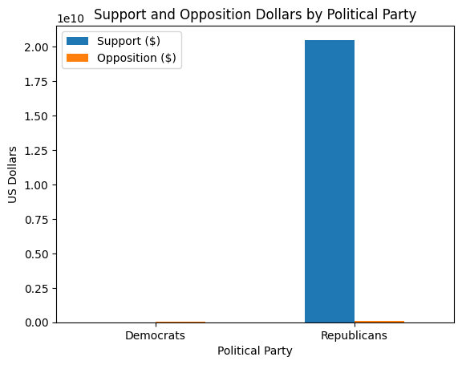

```python
democrat_support_total = df[(df['support_oppose_indicator'] == 'S') & (df['candidate_party'] == 'DEM')]['expenditure_amount'].sum()
democrat_oppose_total = df[(df['support_oppose_indicator'] == 'O') & (df['candidate_party'] == 'DEM')]['expenditure_amount'].sum()
republican_support_total = df[(df['support_oppose_indicator'] == 'S') & (df['candidate_party'] == 'REP')]['expenditure_amount'].sum()
republican_oppose_total = df[(df['support_oppose_indicator'] == 'O') & (df['candidate_party'] == 'REP')]['expenditure_amount'].sum()

support_totals = [democrat_support_total, republican_support_total]
opposition_totals = [democrat_oppose_total, republican_oppose_total]
index = ['Democrats', 'Republicans']
totals = pd.DataFrame({'Support ($)': support_totals, 'Opposition ($)': opposition_totals}, index=index)
totals.plot.bar(rot=0)
plt.title("Support and Opposition Dollars by Political Party")
plt.xlabel("Political Party")
plt.ylabel("US Dollars")

print("Democrat support total was $%.2f" % (democrat_support_total))
print("Democrat opposition total was $%.2f" % (democrat_oppose_total))
print("Republican support total was $%.2f" % (republican_support_total))
print("Republican opposition total was $%.2f" % (republican_oppose_total))
```

Wow, the difference in support between the parties is quite large -- let's investigate.

```python
df[(df['support_oppose_indicator'] == 'S') & (df['candidate_party'] == 'REP')].groupby('candidate_name')['expenditure_amount'].sum().sort_values(ascending=False)
```

```
candidate_name
AKHLAGHY, NADER DR         1.055829e+10
AKHLAGHY, NADER            9.778413e+09
HALEY, NIKKI               9.800230e+07
BURGUM, DOUG               1.872402e+07
SCOTT, TIMOTHY E.          1.604658e+07
TRUMP, DONALD J.           1.245818e+07
RAMASWAMY, VIVEK           6.554191e+06
SUAREZ, FRANCIS X. X.      5.929461e+06
CHRISTIE, CHRISTOPHER J    4.982714e+06
DESANTIS, RON              4.865911e+06
HUTCHINSON, W. ASA         1.140259e+06
HURD, WILLIAM              7.551977e+05
TRUMP, DONALD J            8.503783e+04
TRUMP, DONALD              7.451100e+04
SUAREZ, FRANCIS X.         1.242612e+04
Name: expenditure_amount, dtype: float64
```

```python
df = df[df['candidate_last_name'] != 'AKHLAGHY']
df[(df['support_oppose_indicator'] == 'S') & (df['candidate_party'] == 'REP')].groupby('candidate_name')['expenditure_amount'].sum().sort_values(ascending=False)
```

```
candidate_name
HALEY, NIKKI               98002297.48
BURGUM, DOUG               18724023.22
SCOTT, TIMOTHY E.          16046575.01
TRUMP, DONALD J.           12458179.17
RAMASWAMY, VIVEK            6554190.89
SUAREZ, FRANCIS X. X.       5929460.65
CHRISTIE, CHRISTOPHER J     4982713.53
DESANTIS, RON               4865910.70
HUTCHINSON, W. ASA          1140258.67
HURD, WILLIAM                755197.72
TRUMP, DONALD J               85037.83
TRUMP, DONALD                 74511.00
SUAREZ, FRANCIS X.            12426.12
Name: expenditure_amount, dtype: float64
```

Ok, we've successfully removed those outliers. Let's take another look at the support/opposition bar chart.

```
Democrat support total was $4280215.08
Democrat opposition total was $26437045.61
Republican support total was $169630781.99
Republican opposition total was $84269839.77
Ratio of independent Republican support dollars to independent Democrat support dollars is 39.6
Ratio of independent Republican opposition dollars to independent Democrat opposition dollars is 3.2
```

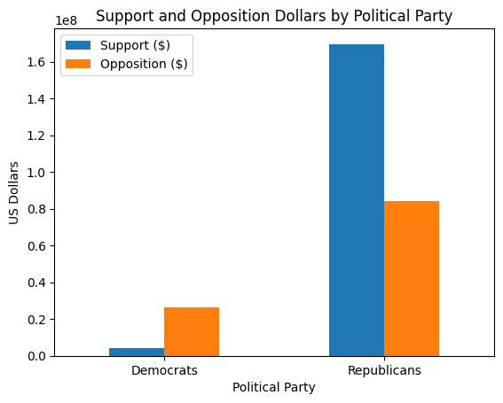

```python
democrat_support_total = df[(df['support_oppose_indicator'] == 'S') & (df['candidate_party'] == 'DEM')]['expenditure_amount'].sum()
democrat_oppose_total = df[(df['support_oppose_indicator'] == 'O') & (df['candidate_party'] == 'DEM')]['expenditure_amount'].sum()
republican_support_total = df[(df['support_oppose_indicator'] == 'S') & (df['candidate_party'] == 'REP')]['expenditure_amount'].sum()
republican_oppose_total = df[(df['support_oppose_indicator'] == 'O') & (df['candidate_party'] == 'REP')]['expenditure_amount'].sum()

support_totals = [democrat_support_total, republican_support_total]
opposition_totals = [democrat_oppose_total, republican_oppose_total]
index = ['Democrats', 'Republicans']
totals = pd.DataFrame({'Support ($)': support_totals, 'Opposition ($)': opposition_totals}, index=index)
totals.plot.bar(rot=0)
plt.title("Support and Opposition Dollars by Political Party")
plt.xlabel("Political Party")
plt.ylabel("US Dollars")

print("Democrat support total was $%.2f" % (democrat_support_total))
print("Democrat opposition total was $%.2f" % (democrat_oppose_total))
print("Republican support total was $%.2f" % (republican_support_total))
print("Republican opposition total was $%.2f" % (republican_oppose_total))

print("Ratio of independent Republican support dollars to independent Democrat support dollars is %.1f" % (republican_support_total / democrat_support_total))
print("Ratio of independent Republican opposition dollars to independent Democrat opposition dollars is %.1f" % (republican_oppose_total / democrat_oppose_total))
```

#### Exploration conclusion 1:

After checking for any other outliers, we have the above bar chart. As we can see, much more money is spent with regards to Republican presidential candidates than Democratic presidential candidates.

Republicans have 39.6 times the independent support dollars as Democrats.

Republicans have 3.2 times the independent opposition dollars as Democrats.

These ratios tell a real world story, which we'll discuss in the final section of this tutorial.

Next, I'm interested to see if the distribution of the expenditure amounts of 24- and 48-hour reports are different or the same. For more information about 24-hour and 48-hour reports, see [this link](https://www.fec.gov/campaign-finance-data/independent-expenditures-file-description/).

Essentially, 24-hour reports must be reported sooner and have a lower threshold of funds raised before they are required to be reported.

First let's check to see if the expenditure amounts are normally distributed for each report type:

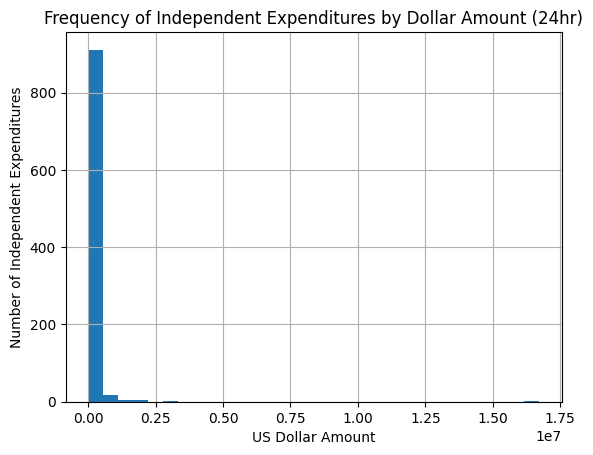

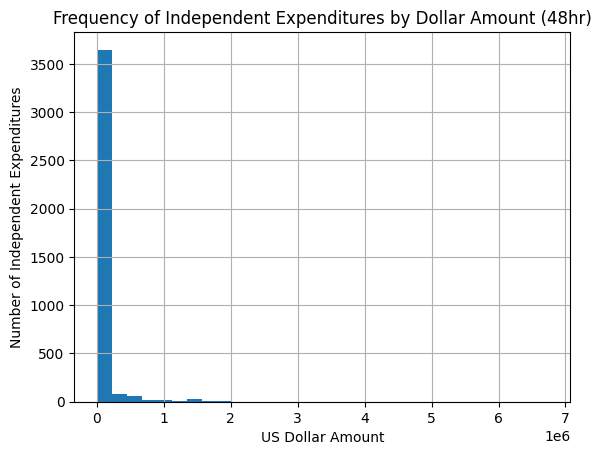

```python
reports_48hr = df[(df['report_type'] == 48) & (df['expenditure_amount'] >= 10)][['committee_name', 'expenditure_amount']]
reports_24hr = df[(df['report_type'] == 24) & (df['expenditure_amount'] >= 10)][['committee_name', 'expenditure_amount']]

reports_24hr.hist(column='expenditure_amount', bins=30)
plt.title('Frequency of Independent Expenditures by Dollar Amount (24hr)')
plt.xlabel('US Dollar Amount')
plt.ylabel('Number of Independent Expenditures')

reports_48hr.hist(column='expenditure_amount', bins=30)
plt.title('Frequency of Independent Expenditures by Dollar Amount (48hr)')
plt.xlabel('US Dollar Amount')
plt.ylabel('Number of Independent Expenditures')
```

These histograms seem to be very skewed. Let's apply a log transform to the data to see if we can get them to resemble something more like a normal distribution. I'd like a normal distribution in order to run a t-test, which assumes normality.

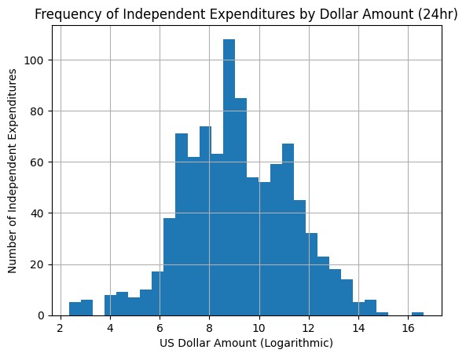

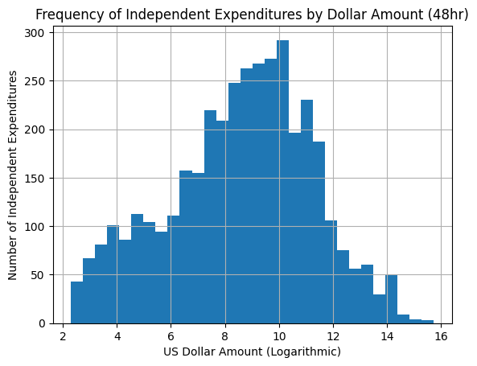

```python
reports_24hr['expenditure_amount'] = np.log(reports_24hr['expenditure_amount'])
reports_48hr['expenditure_amount'] = np.log(reports_48hr['expenditure_amount'])

reports_24hr.hist(column='expenditure_amount', bins=30)
plt.title('Frequency of Independent Expenditures by Dollar Amount (24hr)')
plt.xlabel('US Dollar Amount (Logarithmic)')
plt.ylabel('Number of Independent Expenditures')

reports_48hr.hist(column='expenditure_amount', bins=30)
plt.title('Frequency of Independent Expenditures by Dollar Amount (48hr)')
plt.xlabel('US Dollar Amount (Logarithmic)')
plt.ylabel('Number of Independent Expenditures')
```

Ok, that looks a lot closer to a normal distribution. Let's check what the QQ plots for these distributions look like. Essentially, a [QQ plot](https://library.virginia.edu/data/articles/understanding-q-q-plots) helps us visualize how close our distribution is to being normal.

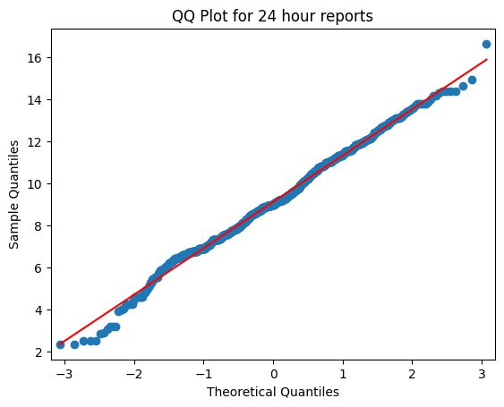

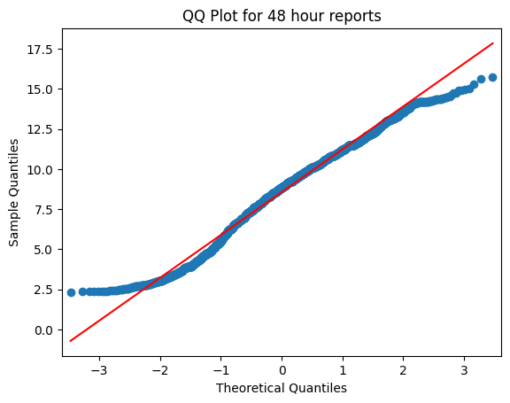

```python
plt.clf()

sm.qqplot(reports_24hr['expenditure_amount'], line='s')
plt.title("QQ Plot for 24 hour reports")


sm.qqplot(reports_48hr['expenditure_amount'], line='s')
plt.title("QQ Plot for 48 hour reports")
```

Since we now have a pretty normal distribution, let's run a [t-test](https://www.investopedia.com/terms/t/t-test.asp) to compare the means of the two reports. The p-value of a t-test tells us whether or not the means of two normal distributions or similar or not.

Let alpha = 0.05,

H0: The mean dollar amount for 24-hour reports is the same as the distribution of dollar amounts for 48-hour reports.

HA: The mean dollar amount for 24-hour reports is different from the distribution of dollar amounts for 48-hour reports.

```python
res = scipy.stats.ttest_ind(reports_24hr['expenditure_amount'], reports_48hr['expenditure_amount'])
res.pvalue
```

```
4.5035826347526115e-09
```

#### Exploration conclusion 2:

Since the p-value was less than 0.05, we reject the null hypothesis. This means that we can conclude that the distribution of the dollar amounts is different between 24-hour and 48-hour reports. This would make sense, since the reports have different reporting requirements.

Next, let's investigate what this money is being used for.

```python
df['category_code_full'].apply(lambda x: x.strip() if not pd.isnull(x) else x)
df['category_code_full'].value_counts()
```

```
category_code_full
Advertising Expenses                        2317
Administrative/Salary/Overhead Expenses       93
Solicitation and Fundraising Expenses         19
Campaign Materials                            19
Campaign Event Expenses                       13
Travel Expenses                                4
Name: count, dtype: int64
```

While loooking through the data, I noticed a lot of NaN values in the 'category_code_full' column. I wanted to see if I could apply some sort of mode imputation to fix this. For example, if a payee had mostly payments for advertising but some of its expenditures were listed as NaN, I could fill in the missing ones as advertising. But in the vast majority of the cases, either all or none of a payee's expenditures were classified. However, I thought it appropriate to fill in the category code for any payee with 'MEDIA' or 'ADVERTISING' in its name as advertising, since many such payees fit this criteria.

```python
def fill_category_code(row):
    if pd.isnull(row['category_code_full']):
        if any(kw in row['payee_name'] for kw in ['MEDIA', 'ADVERTISING']):
            row['category_code_full'] = 'Advertising Expenses '
    return row

df = df.apply(fill_category_code, axis=1)

df['category_code_full'].value_counts()
```

```
category_code_full
Advertising Expenses                        2934
Administrative/Salary/Overhead Expenses       93
Solicitation and Fundraising Expenses         19
Campaign Materials                            19
Campaign Event Expenses                       13
Travel Expenses                                4
Name: count, dtype: int64
```

Ok, imputation done. Let's take a look at the box whisker plots for each spending category.

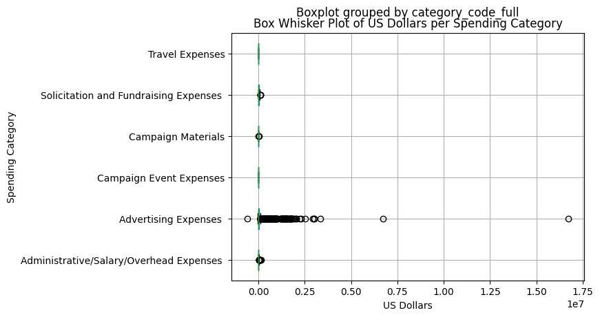

```python
df.boxplot(column='expenditure_amount', by='category_code_full', vert=False)
plt.ylabel('Spending Category')
plt.xlabel("US Dollars")
plt.title("Box Whisker Plot of US Dollars per Spending Category")
```

That's a lot of outliers. Let's not show them so we can actually see what's going on with the plot.

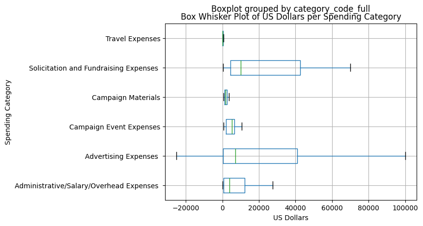

```python
df.boxplot(column='expenditure_amount', by='category_code_full', vert=False, showfliers=False)
plt.ylabel('Spending Category')
plt.xlabel("US Dollars")
plt.title("Box Whisker Plot of US Dollars per Spending Category")
```

Let's take a look at the means of each -- I'm expecting to see that Advertising has the highest mean by far, judging by the magnitude and number of outliers we saw with the box whisker plot.

```python
df.groupby('category_code_full')['expenditure_amount'].mean().sort_values(ascending=False)
```

```
category_code_full
Advertising Expenses                        95902.114881
Solicitation and Fundraising Expenses       29848.526316
Administrative/Salary/Overhead Expenses     15496.881183
Campaign Event Expenses                      4865.162308
Campaign Materials                           3575.832105
Travel Expenses                               203.877500
Name: expenditure_amount, dtype: float64
```

As expected, Advertising Expenses had the highest mean.

Let's take a look at the sum of each category for good measure.

```python
df.groupby('category_code_full')['expenditure_amount'].sum().sort_values(ascending=False)
```

```
category_code_full
Advertising Expenses                        2.813768e+08
Administrative/Salary/Overhead Expenses     1.441210e+06
Solicitation and Fundraising Expenses       5.671220e+05
Campaign Materials                          6.794081e+04
Campaign Event Expenses                     6.324711e+04
Travel Expenses                             8.155100e+02
Name: expenditure_amount, dtype: float64
```

#### Exploration conclusion 3:

As the count, mean, and sum show, Advertising Expenses dominate the expenditures. We'll discuss this more at the end of this tutorial.

Now let's move on to the primary analysis, which aims to answer the question "Is there any correlation between total contributions and ratios of dollars per individual contribution across the different individual contribution brackets?" This question is a bit wordy, but it will become clear soon in the next section.

## 4. Primary Analysis

Let's import a dataset that tracks how much total funding a candidate receives from contributions from various size brackets.

```python
size_df = pd.read_csv('Contributions_by_Size.csv')
size_df[size_df['CANDIDATE_NAME'].str.contains('Biden')]
```

|  | SIZE_OF_CONTRIBUTION | CANDIDATE_ID | CANDIDATE_NAME | CONTRIB_RECEIPT_AMOUNT |
| --- | --- | --- | --- | --- |
| 110 | $200 and under | P80000722 | Biden, Joseph R Jr | 1.002875e+08 |
| 111 | $200.01-$499 | P80000722 | Biden, Joseph R Jr | 1.296426e+07 |
| 112 | $500-$999 | P80000722 | Biden, Joseph R Jr | 1.022215e+07 |
| 113 | $1000-$1999 | P80000722 | Biden, Joseph R Jr | 1.710745e+07 |
| 114 | $2000 and over | P80000722 | Biden, Joseph R Jr | 4.400858e+07 |

I would like to see how these proportions correlate to a candidate's total contributions: are the best-funded candidates receiving a lot of support from ordinary people, or not? Is there any correlation at all? To do this, I will use a linear regression model where the features are a candidate's proportion of funding from each size bracket. The model will predict the candidate's total contributions.

First, let's preprocess size_df to ratios instead of absolute numbers.

```python
def calculate_total_contrib(candidate_name):
    return size_df[size_df['CANDIDATE_NAME'] == candidate_name]['CONTRIB_RECEIPT_AMOUNT'].sum()

size_df['TOTAL_CONTRIB'] = size_df['CANDIDATE_NAME'].apply(calculate_total_contrib)
size_df['SIZE_BRACKET_RATIO'] = size_df['CONTRIB_RECEIPT_AMOUNT'] / size_df['TOTAL_CONTRIB']
size_df[size_df['CANDIDATE_NAME'].str.contains('Biden')]
```

|  | SIZE_OF_CONTRIBUTION | CANDIDATE_ID | CANDIDATE_NAME | CONTRIB_RECEIPT_AMOUNT | TOTAL_CONTRIB | SIZE_BRACKET_RATIO |
| --- | --- | --- | --- | --- | --- | --- |
| 110 | $200 and under | P80000722 | Biden, Joseph R Jr | 1.002875e+08 | 1.845899e+08 | 0.543299 |
| 111 | $200.01-$499 | P80000722 | Biden, Joseph R Jr | 1.296426e+07 | 1.845899e+08 | 0.070233 |
| 112 | $500-$999 | P80000722 | Biden, Joseph R Jr | 1.022215e+07 | 1.845899e+08 | 0.055378 |
| 113 | $1000-$1999 | P80000722 | Biden, Joseph R Jr | 1.710745e+07 | 1.845899e+08 | 0.092678 |
| 114 | $2000 and over | P80000722 | Biden, Joseph R Jr | 4.400858e+07 | 1.845899e+08 | 0.238413 |

Now, let's get the list of ratios for each candidate so we can perform our regression. I'm going to remove the All candidates, Democrats, and Republicans from the dataframe since they are aggregate metrics and could alter the analysis in an unwanted way.

```python
candidates = size_df['CANDIDATE_NAME'].drop_duplicates().values[3:]
candidates
```

```
array(['Williamson, Marianne', 'Stein, Jill', 'Haley, Nikki',
       'Ramaswamy, Vivek', 'Kennedy, Robert F Jr.', 'Hutchinson, W. Asa',
       'Binkley, Ryan', 'Scott, Timothy E.', 'Elder, Larry',
       'DeSantis, Ron', 'Pence, Mike', 'Burgum, Doug', 'West, Cornel',
       'Suarez, Francis', 'Hurd, William', 'de la Cruz, Claudia',
       'Uygur, Cenk', 'Phillips, Dean', 'Christie, Chris',
       'Biden, Joseph R Jr', 'Trump, Donald J.'], dtype=object)
```

```python
X = np.array([size_df[size_df['CANDIDATE_NAME'] == candidate_name]['SIZE_BRACKET_RATIO'].to_numpy() for candidate_name in candidates])
X
```

```
array([[0.6869767 , 0.05432128, 0.06573003, 0.07244058, 0.12053142],
       [0.46040775, 0.16764313, 0.09327078, 0.11058732, 0.16809102],
       [0.435471  , 0.06491705, 0.08454993, 0.10233657, 0.31272545],
       [0.55478339, 0.05877843, 0.05608532, 0.07662447, 0.25372839],
       [0.41941187, 0.08212257, 0.0631651 , 0.12450083, 0.31079963],
       [0.34445375, 0.03448907, 0.05199098, 0.12912024, 0.43994596],
       [0.391966  , 0.06370378, 0.08217552, 0.09678533, 0.36536937],
       [0.37653043, 0.03413666, 0.04175285, 0.0787438 , 0.46883626],
       [0.68559684, 0.03576977, 0.03949941, 0.04570931, 0.19342467],
       [0.23250786, 0.03796781, 0.02768074, 0.06626432, 0.63557927],
       [0.50962218, 0.03508657, 0.04007078, 0.07093139, 0.34428909],
       [0.2559944 , 0.0216104 , 0.04247817, 0.13077337, 0.54914366],
       [0.55946176, 0.05932037, 0.07123013, 0.07673929, 0.23324844],
       [0.08876825, 0.00431644, 0.02461312, 0.04265102, 0.83965117],
       [0.528404  , 0.05251715, 0.06399869, 0.08684273, 0.26823743],
       [0.76528425, 0.03238753, 0.0323942 , 0.02999463, 0.1399394 ],
       [0.74262291, 0.09971109, 0.02608302, 0.07649721, 0.05508578],
       [0.2559759 , 0.07587379, 0.05029302, 0.12959834, 0.48825896],
       [0.33063615, 0.05502139, 0.03721139, 0.11903842, 0.45809265],
       [0.54329876, 0.07023278, 0.05537763, 0.09267812, 0.23841271],
       [0.69872058, 0.14771316, 0.07007707, 0.0123117 , 0.07117749]])
```

Now we have X, our feature array. Each row contains the proportion of each size bracket, with the smallest bracket on the left and the largest on the right.

```python
Y = np.array([size_df[size_df['CANDIDATE_NAME'] == candidate_name]['TOTAL_CONTRIB'].to_numpy()[0] for candidate_name in candidates])
Y
```

```
array([3.98829542e+06, 4.31604620e+05, 6.69840264e+07, 1.21008247e+07,
       3.33752294e+07, 1.82041190e+06, 4.79390840e+05, 1.07525179e+07,
       1.37779734e+06, 4.36430911e+07, 5.57979634e+06, 3.17194798e+06,
       1.02555025e+06, 1.42200599e+06, 1.44758606e+06, 1.50026870e+05,
       5.13744240e+05, 1.78484028e+06, 7.73575315e+06, 1.84589914e+08,
       1.20548652e+08])
```

Y, our predictions array, holds the total contributions for each candidate.

```python
from sklearn.linear_model import LinearRegression
model = LinearRegression().fit(X, Y)
print(f'R^2 = {model.score(X, Y)}')
print(model.coef_)
print(model.intercept_)
```

```
R^2 = 0.12997189720724345
[-5.97005461e+07  3.16320859e+08  1.45130437e+08 -3.62265153e+08
 -3.94855962e+07]
68495525.38749684
```

So the model doesn't seem to be very accurate, as we can see from the very low [R^2 score](https://corporatefinanceinstitute.com/resources/data-science/r-squared). Ideally, we would like an R^2 score of 1, which would mean that our model explains all the variance in the data. Let's investigate the data more closely. First, let's define the acronym ROC, which stands for "ratio of contributions" -- this will help the plots look a little more compact. Let's see if there is actually a relationship between the proportion of the smallest bracket and largest bracket:

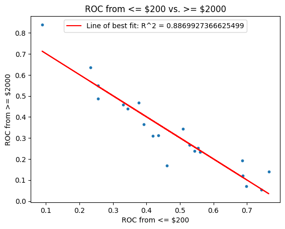

```python
x = X[:, 0].reshape(-1, 1)
y = X[:, 4].reshape(-1, 1)
model_200_2000 = LinearRegression().fit(x, y)
m = model_200_2000.coef_[0][0]
b = model_200_2000.intercept_

f1 = plt.figure()
plt.plot(x, m * x + b, color='red', label=f'Line of best fit: R^2 = {model_200_2000.score(x, y)}')
plt.scatter(x, y, s=10)
plt.title('ROC from <= \$200 vs. >= \$2000')
plt.xlabel('ROC from <= $200')
plt.ylabel('ROC from >= $2000')
plt.legend(loc='upper center')
plt.show()
```

Ok, there seems to be a pretty strong relationship, with R^2 = 0.887. Maybe we can reduce the dimensions of the regression by only using the smallest and largest ROCs as features. Let's try it.

```python
xy = np.stack((X[:, 0], X[:, 4]), axis=1)
model_200_2000 = LinearRegression().fit(xy, Y)
c1 = model_200_2000.coef_[0]
c2 = model_200_2000.coef_[1]
b = model_200_2000.intercept_
r2 = model_200_2000.score(xy, Y)
print(r2)
```

```
0.04431538033726723
```

Ok, the R^2 score is even closer to zero now. That didn't seem to help. Going back to the model that considered all five brackets, the coefficients for the middle three brackets were the highest, possibly indicating that they are more important as features. Let's try a model using those features only and see if we can get a better R^2 score.

```python
x123 = np.stack((X[:, 1], X[:, 2], X[:, 3]), axis=1)
model123 = LinearRegression().fit(x123, Y)
model123.score(x123, Y)
```

```
0.12605800191101446
```

The R^2 score is still very poor, unfortunately. I'm starting to suspect that heavy correlation between the ROCs between the brackets is hurting the model's efficacy. Let's use a pivot table to make each bracket into its own column for each candidate so we can make a correlation matrix.

```python
pivot_df = size_df.pivot_table(index='CANDIDATE_NAME', columns='SIZE_OF_CONTRIBUTION', values='CONTRIB_RECEIPT_AMOUNT', aggfunc='sum')
pivot_df.reset_index(inplace=True)
pivot_df.head()
```

| SIZE_OF_CONTRIBUTION | CANDIDATE_NAME | $1000-$1999 | $200 and under | $200.01-$499 | $2000 and over | $500-$999 |
| --- | --- | --- | --- | --- | --- | --- |
| 0 | All candidates, | 37220346.03 | 2.619238e+08 | 42051576.05 | 1.315044e+08 | 30222963.88 |
| 1 | Biden, Joseph R Jr | 17107446.31 | 1.002875e+08 | 12964262.48 | 4.400858e+07 | 10222152.58 |
| 2 | Binkley, Ryan | 46398.00 | 1.879049e+05 | 30539.01 | 1.751547e+05 | 39394.19 |
| 3 | Burgum, Doug | 414806.32 | 8.120009e+05 | 68547.05 | 1.741855e+06 | 134738.55 |
| 4 | Christie, Chris | 920851.81 | 2.557720e+06 | 425631.90 | 3.543692e+06 | 287858.13 |

```python
pivot_df[['$200 and under', '$200.01-$499', '$500-$999', '$1000-$1999', '$2000 and over']].corr()
```

| SIZE_OF_CONTRIBUTION | $200 and under | $200.01-$499 | $500-$999 | $1000-$1999 | $2000 and over |
| --- | --- | --- | --- | --- | --- |
| $200 and under | 1.000000 | 0.990407 | 0.995301 | 0.955184 | 0.960759 |
| $200.01-$499 | 0.990407 | 1.000000 | 0.989008 | 0.910042 | 0.939606 |
| $500-$999 | 0.995301 | 0.989008 | 1.000000 | 0.955210 | 0.970708 |
| $1000-$1999 | 0.955184 | 0.910042 | 0.955210 | 1.000000 | 0.969532 |
| $2000 and over | 0.960759 | 0.939606 | 0.970708 | 0.969532 | 1.000000 |

The variables are all very strongly correlated with one another. It seems that finding a correlation between these features and the predictor is not possible.

## 5. Visualization

Let's visualize the contributions using a stacked bar chart to see if we can confirm or deny this visually.

```python
bar_df = size_df[['CANDIDATE_NAME', 'TOTAL_CONTRIB']].drop_duplicates().iloc[3:]
lt200_df = size_df[size_df['SIZE_OF_CONTRIBUTION'] == '$200 and under'][['CANDIDATE_NAME', 'CONTRIB_RECEIPT_AMOUNT']].iloc[3:]

lt500_df = size_df[size_df['SIZE_OF_CONTRIBUTION'] == '$200.01-$499'][['CANDIDATE_NAME', 'CONTRIB_RECEIPT_AMOUNT']].iloc[3:]
lt500_df['CONTRIB_RECEIPT_AMOUNT'] = lt500_df['CONTRIB_RECEIPT_AMOUNT'].values + lt200_df['CONTRIB_RECEIPT_AMOUNT'].values

lt1000_df = size_df[size_df['SIZE_OF_CONTRIBUTION'] == '$500-$999'][['CANDIDATE_NAME', 'CONTRIB_RECEIPT_AMOUNT']].iloc[3:]
lt1000_df['CONTRIB_RECEIPT_AMOUNT'] = lt1000_df['CONTRIB_RECEIPT_AMOUNT'].values + lt500_df['CONTRIB_RECEIPT_AMOUNT'].values

lt2000_df = size_df[size_df['SIZE_OF_CONTRIBUTION'] == '$1000-$1999'][['CANDIDATE_NAME', 'CONTRIB_RECEIPT_AMOUNT']].iloc[3:]
lt2000_df['CONTRIB_RECEIPT_AMOUNT'] = lt2000_df['CONTRIB_RECEIPT_AMOUNT'].values + lt1000_df['CONTRIB_RECEIPT_AMOUNT'].values
```

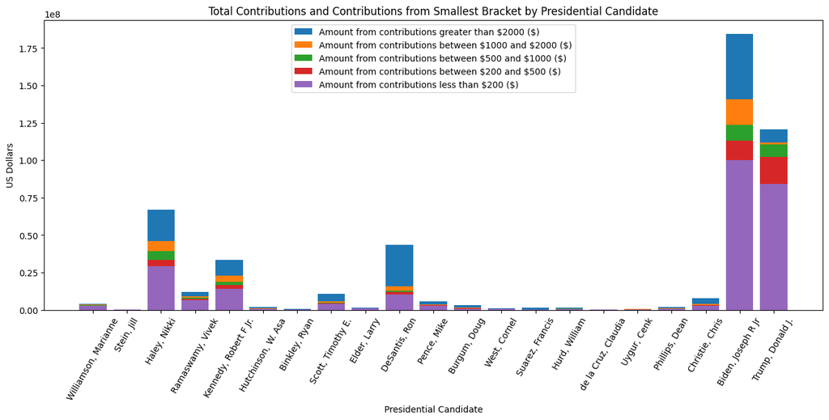

```python
f_bar = plt.figure()
plt.bar(bar_df['CANDIDATE_NAME'], bar_df['TOTAL_CONTRIB'], label="Amount from contributions greater than \$2000 (\$)")
plt.bar(bar_df['CANDIDATE_NAME'], lt2000_df['CONTRIB_RECEIPT_AMOUNT'], label="Amount from contributions between \$1000 and \$2000 (\$)")
plt.bar(bar_df['CANDIDATE_NAME'], lt1000_df['CONTRIB_RECEIPT_AMOUNT'], label="Amount from contributions between \$500 and \$1000 (\$)")
plt.bar(bar_df['CANDIDATE_NAME'], lt500_df['CONTRIB_RECEIPT_AMOUNT'], label="Amount from contributions between \$200 and \$500 (\$)")
plt.bar(bar_df['CANDIDATE_NAME'], lt200_df['CONTRIB_RECEIPT_AMOUNT'], label="Amount from contributions less than \$200 (\$)")

f_bar.set_size_inches(16,6)
plt.xticks(rotation=60)
plt.xlabel("Presidential Candidate")
plt.ylabel("US Dollars")
plt.legend(loc='upper center')
plt.title("Total Contributions and Contributions from Smallest Bracket by Presidential Candidate")
```

## 6. Insights and Conclusions

From the exploratory data analysis, I would like to discuss two points from our findings:

1. We see that most funding from independent expenditures is spent both supporting and opposing candidates from the Republican party.

This illustrates the competition within the party to become the nominee, which results in many dollars spent both supporting and opposing various Republican candidates. Meanwhile, Joe Biden is all but confirmed as the Democratic nominee, so spending money supporting or opposing other Democratic candidates probably would not be particularly productive.

3. We see that advertising expenses dominate the independent expenditure contribution category.

This would make sense, since candidates need to get their names, faces, and politics out to the masses if they are to receive votes. So, it's no surprise that advertising on traditional media avenues, like TV, still dominate spending. In fact, [this article](https://insight.kellogg.northwestern.edu/article/how-much-do-campaign-ads-matter) from Northwestern University found that running only positive ads and no negative ads could possibly have swung the 2000 election in Al Gore's favor, demonstrating the power and importance that advertising has during election season.

After creating the initial linear regression model and performing some deeper analysis, we can conclude that there is no correlation between the ratios of contributions and the total contributions for a given candidate. The best R^2 value we were able to obtain was less than 0.13, far from the ideal value of 1.

The above bar chart helps show the lack of correlation: it seems that for the most part, candidates receive the bulk of their funding from contributions less than 200 dollars and from contributions greater than 2000 dollars.

Even though we did not find a correlation between our features and predictor, we still learned some interesting things about campaign funding.

### Works Cited and Further Reading

[How Much Do Campaign Ads Matter?](https://insight.kellogg.northwestern.edu/article/how-much-do-campaign-ads-matter)

[R-Squared](https://corporatefinanceinstitute.com/resources/data-science/r-squared)

[T-Test](https://www.investopedia.com/terms/t/t-test.asp)

[QQ Plots](https://library.virginia.edu/data/articles/understanding-q-q-plots)